# R Notebook - Visualização de Dados com ggplot2 - Aula 2

## Camada 7: Tema

A camada de tema ajusta aspectos não relacionados diretamente com os dados, como cores de fundo, estilos de eixos e legendas.

### Exemplo com diferentes temas:

[figure not shown]

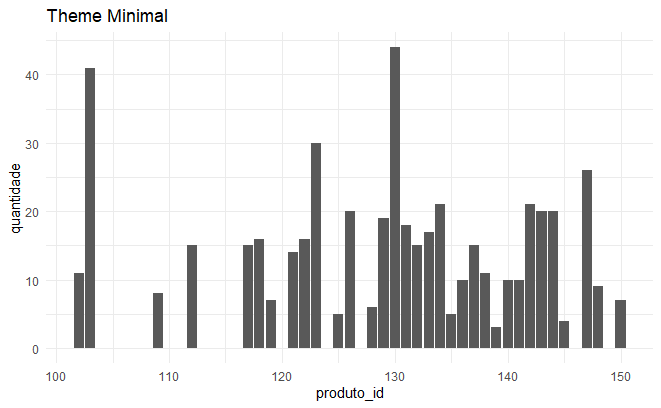

```r
# Gráfico com theme_minimal()
p2 <- ggplot(vendas, aes(x = produto_id, y = quantidade)) +
  geom_col() +
  theme_minimal() +
  labs(title = "Theme Minimal")

p2
```

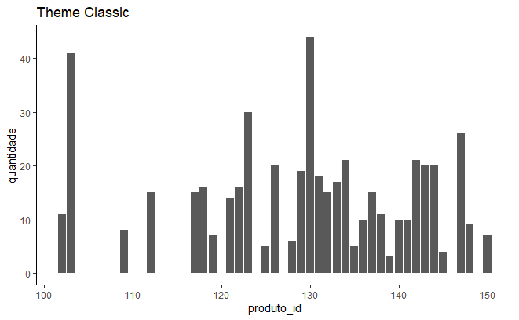

```r
# Gráfico com theme_classic()
p3 <- ggplot(vendas, aes(x = produto_id, y = quantidade)) +
  geom_col() +
  theme_classic() +
  labs(title = "Theme Classic")
p3
```

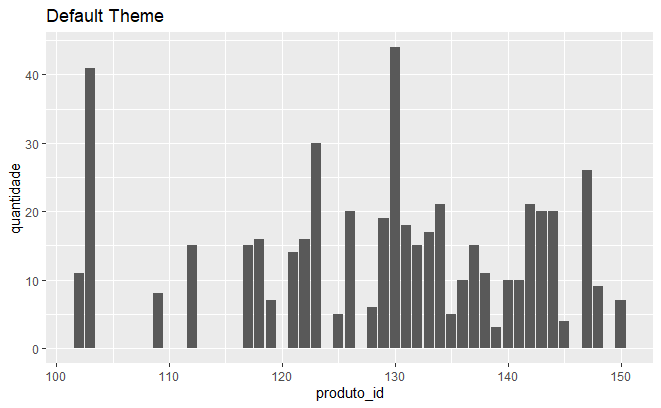

```r
# Gráfico padrão sem definir tema
p4 <- ggplot(vendas, aes(x = produto_id, y = quantidade)) +
  geom_col() +
  labs(title = "Default Theme")
p4
```

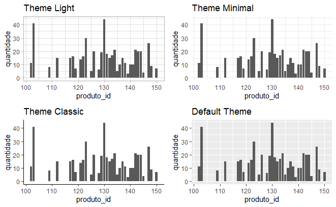

```r
# Exibindo os gráficos em um grid
gridExtra::grid.arrange(p1, p2, p3, p4, ncol = 2)
```

### Funções de Tema Disponíveis:

- `theme_light()`: Tema claro.
- `theme_minimal()`: Tema minimalista.
- `theme_classic()`: Tema clássico.
- `theme_void()`: Tema sem eixos, útil para mapas.
- `theme_dark()`: Tema escuro.

## Pacotes para Recursos Interativos

Além do ggplot2, o R possui vários pacotes para visualizações interativas que são ideais para exibição em ambientes web:

- **plotly**: Converte gráficos do ggplot2 em gráficos interativos.
- **highcharter**: Interface R para a biblioteca Highcharts.
- **leaflet**: Visualizações de mapas interativas.
- **echarts4r**: Interface para a biblioteca ECharts.

Esses pacotes permitem que você crie gráficos interativos que podem ser incorporados em dashboards ou relatórios web.